# M2.855_20212_PEC1-Enunciado

[figure not shown]

M2.855 · Modelos avanzados de minería de datos · PEC1

2021-2 · Máster universitario en Ciencia de datos (Data science)

Estudios de Informática, Multimedia y Telecomunicación

# PEC 1: Preparación de datos

A lo largo de esta práctica veremos como aplicar diferentes técnicas para la carga y preparación de datos:

1. Carga de un conjunto de datos
2. Análisis de los datos  
   2.1 Análisis estadístico básico  
   2.2 Análisis exploratorio de los datos
3. Reducción de la dimensionalidad
4. Entrenamiento y test

**Importante:** Cada uno de los ejercicios puede suponer varios minutos de ejecución, por lo que la entrega debe hacerse en formato notebook y en formato html, donde se vea el código, los resultados y comentarios de cada ejercicio. Se puede exportar el notebook a html desde el menú File $\to$ Download as $\to$ HTML.

**Importante:** Existe un tipo de celda especial para albergar texto. Este tipo de celda os será muy útil para responder a las diferentes preguntas teóricas planteadas a lo largo de cada PEC. Para cambiar el tipo de celda a este tipo, en el menú: Cell $\to$ Cell Type $\to$ Markdown.

**Importante:** La solución planteada no puede utilizar métodos, funciones o parámetros declarados "deprecated" en futuras versiones, a excepción de la carga de datos cómo se indica posteriormente.

Para eso necesitaremos las siguientes librerías:

**Nombre y apellidos:** Victor H. Ayala Sanchez

## Tabla de Contenidos

- 1. Carga del conjunto de datos)
- 2. Análisis de los datos)
- 3. Reducción de la dimensionalidad)
- 4. Entrenamiento y test)

```python
import numpy as np
import pandas as pd
import seaborn as sns
from sklearn import datasets
from sklearn import preprocessing
from sklearn.manifold import TSNE
from sklearn.decomposition import PCA
from sklearn.ensemble import RandomForestRegressor
from sklearn.metrics import r2_score, mean_absolute_error
from sklearn.model_selection import train_test_split, cross_val_score
from sklearn.model_selection import validation_curve
from sklearn.model_selection import GridSearchCV

import matplotlib.pyplot as plt

pd.set_option('display.max_columns', None)
seed = 100

%matplotlib inline
```

# 1. Carga del conjunto de datos (1 punto)

En primer lugar, debéis cargar el conjunto de datos "Boston house prices", el cual contiene el valor de las casas en diferentes zonas de Boston dependiendo de múltiples factores. Se puede descargar de internet [aquí](https://archive.ics.uci.edu/ml/machine-learning-databases/housing/) o se puede cargar directamente desde la librería "scikit-learn", que incorpora un conjunto de datasets muy conocidos y usados para la minería de datos y machine learning https://scikit-learn.org/stable/datasets.html.

Para los ejercicios de esta PEC, utilizaremos como variable respuesta a "MEDV": la mediana del valor de las casas en una zona de Boston (en k$ -miles de dólares-).

**Ejercicio:**  
Cargad el conjunto de datos "boston house-prices dataset" y mostrad:

- El número y nombre de los atributos (variables que podrían ser usadas para predecir la respuesta "MEDV")
- El número de filas del conjunto de datos
- Verificad si hay o no "missing values" y en qué columnas

Sugerencia: Si usáis sklearn (sklearn.datasets.load_boston), explorad las diferents 'keys' del objecto obtenido.  
Sugerencia: Igual os resulta útil pasar los datos (atributos + respuesta) a un dataframe de pandas.

Nota: Al cargar el conjunto de datos desde la librería "scikit-learn" observaréis que el conjunto de datos no va a ser mantenido en el futuro debido a un problema ético en los datos, el cual no interfiere con el objetivo de la presente PEC (recolección y análisis de datos).

```python
boston = datasets.load_boston()
print(boston.DESCR)
```

```
.. _boston_dataset:

Boston house prices dataset
---------------------------

**Data Set Characteristics:**

    :Number of Instances: 506

    :Number of Attributes: 13 numeric/categorical predictive. Median Value (attribute 14) is usually the target.

    :Attribute Information (in order):
        - CRIM     per capita crime rate by town
        - ZN       proportion of residential land zoned for lots over 25,000 sq.ft.
        - INDUS    proportion of non-retail business acres per town
        - CHAS     Charles River dummy variable (= 1 if tract bounds river; 0 otherwise)
        - NOX      nitric oxides concentration (parts per 10 million)
        - RM       average number of rooms per dwelling
        - AGE      proportion of owner-occupied units built prior to 1940
        - DIS      weighted distances to five Boston employment centres
        - RAD      index of accessibility to radial highways
        - TAX      full-value property-tax rate per $10,000
        - PTRATIO  pupil-teacher ratio by town
        - B        1000(Bk - 0.63)^2 where Bk is the proportion of black people by town
        - LSTAT    % lower status of the population
        - MEDV     Median value of owner-occupied homes in $1000's

    :Missing Attribute Values: None

    :Creator: Harrison, D. and Rubinfeld, D.L.

This is a copy of UCI ML housing dataset.
https://archive.ics.uci.edu/ml/machine-learning-databases/housing/


This dataset was taken from the StatLib library which is maintained at Carnegie Mellon University.

The Boston house-price data of Harrison, D. and Rubinfeld, D.L. 'Hedonic
prices and the demand for clean air', J. Environ. Economics & Management,
vol.5, 81-102, 1978.   Used in Belsley, Kuh & Welsch, 'Regression diagnostics
...', Wiley, 1980.   N.B. Various transformations are used in the table on
pages 244-261 of the latter.

The Boston house-price data has been used in many machine learning papers that address regression
problems.

.. topic:: References

   - Belsley, Kuh & Welsch, 'Regression diagnostics: Identifying Influential Data and Sources of Collinearity', Wiley, 1980. 244-261.
   - Quinlan,R. (1993). Combining Instance-Based and Model-Based Learning. In Proceedings on the Tenth International Conference of Machine Learning, 236-243, University of Massachusetts, Amherst. Morgan Kaufmann.
```

[output not shown]

```python
cols = list(boston.feature_names)

df = pd.DataFrame(boston.data, columns = cols)
df['MEDV'] = boston.target
df.sample(5)
```

|  | CRIM | ZN | INDUS | CHAS | NOX | RM | AGE | DIS | RAD | TAX | PTRATIO | B | LSTAT | MEDV |
| --- | --- | --- | --- | --- | --- | --- | --- | --- | --- | --- | --- | --- | --- | --- |
| 379 | 17.86670 | 0.0 | 18.10 | 0.0 | 0.671 | 6.223 | 100.0 | 1.3861 | 24.0 | 666.0 | 20.2 | 393.74 | 21.78 | 10.2 |
| 190 | 0.09068 | 45.0 | 3.44 | 0.0 | 0.437 | 6.951 | 21.5 | 6.4798 | 5.0 | 398.0 | 15.2 | 377.68 | 5.10 | 37.0 |
| 70 | 0.08826 | 0.0 | 10.81 | 0.0 | 0.413 | 6.417 | 6.6 | 5.2873 | 4.0 | 305.0 | 19.2 | 383.73 | 6.72 | 24.2 |
| 39 | 0.02763 | 75.0 | 2.95 | 0.0 | 0.428 | 6.595 | 21.8 | 5.4011 | 3.0 | 252.0 | 18.3 | 395.63 | 4.32 | 30.8 |
| 46 | 0.18836 | 0.0 | 6.91 | 0.0 | 0.448 | 5.786 | 33.3 | 5.1004 | 3.0 | 233.0 | 17.9 | 396.90 | 14.15 | 20.0 |

Los atributos fueron mostrados anteriormente con el método **DESCR**

```python
print("El Número de atributos es: {}".format(df.shape[1]-1))
print("El Número de registros es: {}".format(df.shape[0]))
print("El Número de registros faltantes o ausentes es: {}".format(df.isna().sum().sum()))
```

```
El Número de atributos es: 13
El Número de registros es: 506
El Número de registros faltantes o ausentes es: 0
```

```python
df.info()
```

```
<class 'pandas.core.frame.DataFrame'>
RangeIndex: 506 entries, 0 to 505
Data columns (total 14 columns):
 #   Column   Non-Null Count  Dtype
---  ------   --------------  -----
 0   CRIM     506 non-null    float64
 1   ZN       506 non-null    float64
 2   INDUS    506 non-null    float64
 3   CHAS     506 non-null    float64
 4   NOX      506 non-null    float64
 5   RM       506 non-null    float64
 6   AGE      506 non-null    float64
 7   DIS      506 non-null    float64
 8   RAD      506 non-null    float64
 9   TAX      506 non-null    float64
 10  PTRATIO  506 non-null    float64
 11  B        506 non-null    float64
 12  LSTAT    506 non-null    float64
 13  MEDV     506 non-null    float64
dtypes: float64(14)
memory usage: 55.5 KB
```

# 2. Análisis de los datos (3 puntos)

## 2.1 Análisis estadístico básico

**Ejercicio:**  
Realizad un análisis estadístico básico:

- Variables categóricas:
- Calculad la frecuencia
- Haced un gráfico de barras
- Variables numéricas:
- Calculad estadísticos descriptivos básicos: media, mediana, desviación estandard, ...
- Haced un histograma de las variables INDUS, AGE y MEDV

Sugerencia: podéis usar la librería 'pandas' y sus funciones 'describe' y 'value_counts', así como las funciones 'bar' e 'hist' de matplotlib.

### Análizsis de variables categóricas:

```python
freq = pd.DataFrame(df.groupby(['CHAS'], as_index=False)['CHAS'].count())
freq['%'] = [round((i / sum(freq.CHAS)),5) * 100 for i in freq.CHAS]
freq
```

|  | CHAS | % |
| --- | --- | --- |
| 0 | 471 | 93.083 |
| 1 | 35 | 6.917 |

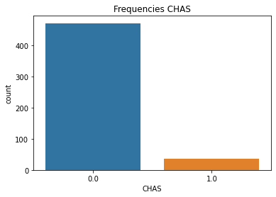

```python
sns.countplot(x=df.CHAS, data=df)
plt.title('Frequencies CHAS')
```

### Análizsis de variables numéricas:

```python
df.loc[:, df.columns != 'CHAS'].describe().T
```

|  | count | mean | std | min | 25% | 50% | 75% | max |
| --- | --- | --- | --- | --- | --- | --- | --- | --- |
| CRIM | 506.0 | 3.613524 | 8.601545 | 0.00632 | 0.082045 | 0.25651 | 3.677083 | 88.9762 |
| ZN | 506.0 | 11.363636 | 23.322453 | 0.00000 | 0.000000 | 0.00000 | 12.500000 | 100.0000 |
| INDUS | 506.0 | 11.136779 | 6.860353 | 0.46000 | 5.190000 | 9.69000 | 18.100000 | 27.7400 |
| NOX | 506.0 | 0.554695 | 0.115878 | 0.38500 | 0.449000 | 0.53800 | 0.624000 | 0.8710 |
| RM | 506.0 | 6.284634 | 0.702617 | 3.56100 | 5.885500 | 6.20850 | 6.623500 | 8.7800 |
| AGE | 506.0 | 68.574901 | 28.148861 | 2.90000 | 45.025000 | 77.50000 | 94.075000 | 100.0000 |
| DIS | 506.0 | 3.795043 | 2.105710 | 1.12960 | 2.100175 | 3.20745 | 5.188425 | 12.1265 |
| RAD | 506.0 | 9.549407 | 8.707259 | 1.00000 | 4.000000 | 5.00000 | 24.000000 | 24.0000 |
| TAX | 506.0 | 408.237154 | 168.537116 | 187.00000 | 279.000000 | 330.00000 | 666.000000 | 711.0000 |
| PTRATIO | 506.0 | 18.455534 | 2.164946 | 12.60000 | 17.400000 | 19.05000 | 20.200000 | 22.0000 |
| B | 506.0 | 356.674032 | 91.294864 | 0.32000 | 375.377500 | 391.44000 | 396.225000 | 396.9000 |
| LSTAT | 506.0 | 12.653063 | 7.141062 | 1.73000 | 6.950000 | 11.36000 | 16.955000 | 37.9700 |
| MEDV | 506.0 | 22.532806 | 9.197104 | 5.00000 | 17.025000 | 21.20000 | 25.000000 | 50.0000 |

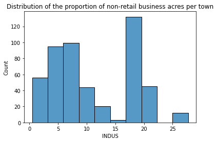

```python
sns.histplot(x='INDUS', data=df)
plt.title('Distribution of the proportion of non-retail business acres per town')
plt.show()
```

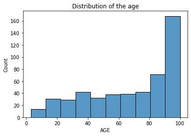

```python
sns.histplot(x='AGE', data=df)
plt.title('Distribution of the age')
plt.show()
```

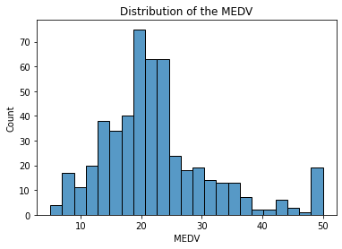

```python
sns.histplot(x='MEDV', data=df)
plt.title('Distribution of the MEDV')
plt.show()
```

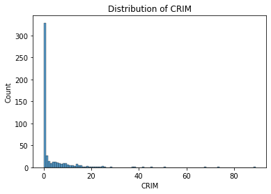

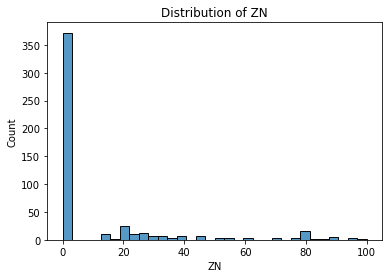

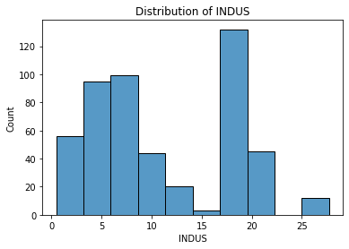

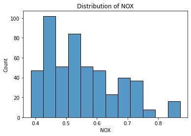

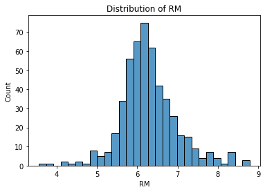

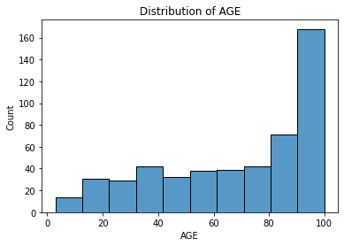

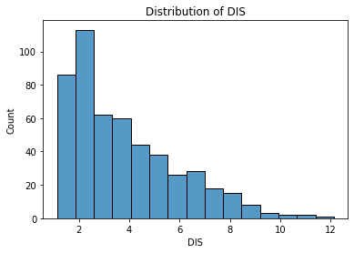

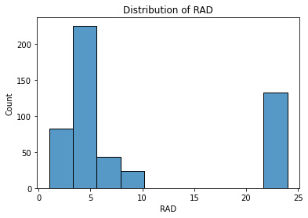

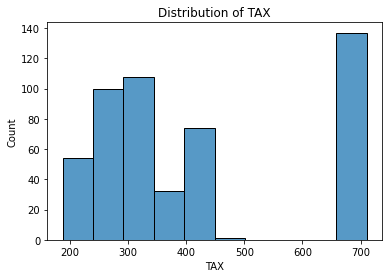

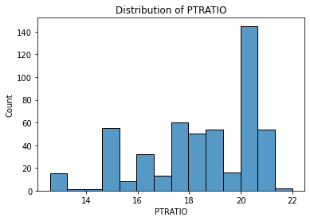

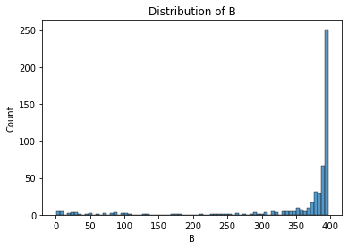

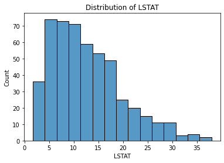

[1 more figures not shown]

```python
for i in list(df.loc[:, df.columns != 'CHAS'].columns):
    print("-------------")
    sns.histplot(x=str(i), data=df)
    plt.title('Distribution of {}'.format(str(i)))
    plt.show()
```

**Análisis:**  
Comentad los resultados.

La variable categórica CHAS es binaria y tiene clases desigualmente distribuídas. A penas el 7% de los registros de casa del dataset son cercanos al río.

Observando tanto la tabla de estadísticos descriptivos como los histogramas graficados podemos notar que diversos features tienen una distribución coleada y además presentan valores extremos; CRIM y ZN son ejemplos claros de lo mencionado con anterioridad, teniendo también valores muy alejados de la media y mediana. En el caso de INDUS y NOX tenemos distribuciones multimodales. RM es el atributo con una distribución más parecida a la normal

## 2.2 Análisis exploratorio de los datos

En este ejercicio exploraremos la relación de los atributos con la variable respuesta, mediante gráficos y analizando las correlaciones de los atributos numéricos.

```python
response = "MEDV"
cat_feat = "CHAS"
num_feats = ['CRIM', 'ZN', 'INDUS', 'NOX', 'RM', 'AGE', 'DIS', 'RAD', 'TAX', 'PTRATIO', 'B', 'LSTAT']
print('Respuesta ("target"):', response)
print("Atributo categórico:", cat_feat)
print("Atributos numéricos:", num_feats)
```

```
Respuesta ("target"): MEDV
Atributo categórico: CHAS
Atributos numéricos: ['CRIM', 'ZN', 'INDUS', 'NOX', 'RM', 'AGE', 'DIS', 'RAD', 'TAX', 'PTRATIO', 'B', 'LSTAT']
```

**Ejercicio:**  
Realizad un gráfico del histograma de valores de la variable respuesta, separado por los posibles valores (clases) del atributo categórico. Para comparar mejor los valores de MEDV para las diferentes clases de CHAS, los histogramas del gráfico tienen que estar sobrepuestos. Añadid una leyenda para saber a qué clase corresponde cada histograma. La finalidad es observar como se distribuye el valor de la respuesta MEDV en función del valor de la clase CHAS, para poder identificar de manera visual y rápida si este atributo categórico está relacionado con diferentes valores de la respuesta.

Sugerencia: podéis usar la función "hist" de la librería "matplotlib", así como su parámetro "alpha" para que se aprecien los histogramas sobrepuestos.  
Sugerencia: para comparar mejor los histogramas, considerad representar la densidad de probabilidad en vez del número de entradas por bin. De este modo, la escala de los histogramas será la misma para cada clase y será fácil de comparar. Podéis usar el parámetro "density" de la misma función "hist".

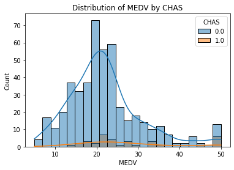

```python
sns.histplot(x='MEDV', data=df, hue='CHAS',kde=True)
plt.title('Distribution of MEDV by CHAS')
plt.show()
```

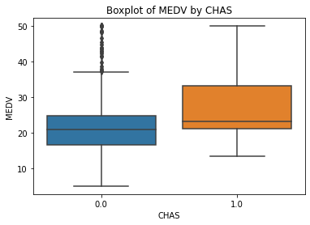

```python
sns.boxplot(x='CHAS', y='MEDV',data=df)
plt.title('Boxplot of MEDV by CHAS')
plt.show()
```

**Análisis:**  
Mirando los histogramas, ¿te parece que el atributo CHAS tendrá algún peso a la hora de predecir la mediana del precio de las casas, MEDV? ¿Porqué?

Mirando tanto los histogramas como los boxplots se nota que la mediana de precios y la distribución de la mediana de precios es un poco mayor en el caso de aquellos registros que son CHAS=1, es decir se encuentran cercanos al río

```python
df[["CHAS","MEDV"]].groupby("CHAS").describe().T
```

|  | CHAS | 0.0 | 1.0 |
| --- | --- | --- | --- |
| MEDV | count | 471.000000 | 35.000000 |
|  | mean | 22.093843 | 28.440000 |
|  | std | 8.831362 | 11.816643 |
|  | min | 5.000000 | 13.400000 |
|  | 25% | 16.600000 | 21.100000 |
|  | 50% | 20.900000 | 23.300000 |
|  | 75% | 24.800000 | 33.150000 |
|  | max | 50.000000 | 50.000000 |

La media, el percentil 25 y 75 de la propiedades cercanas al río son ligeramente mayores a aquellas propiedades que no.

**Ejercicio:**  
Repetid los histogramas anteriores, añadiendo una línea vertical indicando la media de cada uno de los histogramas. Pintad las linias del mismo color que el histograma para que quede claro a cual hacen referencia. Añadid a la leyenda la clase de CHAS y los valores de la media y la desviación estandard en cuestión. La finalidad es verificar numéricamente las diferencias identificadas anteriormente de forma visual.

Sugerencia: podeis usar "axvline", de matplotlib axis, para las linias verticales.

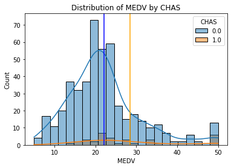

```python
sns.histplot(x='MEDV', data=df, hue='CHAS',kde=True)
plt.axvline(df[df["CHAS"]==0].loc[:, "MEDV"].mean(), color='blue')
plt.axvline(df[df["CHAS"]==1].loc[:, "MEDV"].mean(), color='orange')
plt.title('Distribution of MEDV by CHAS')
plt.show()
```

**Ejercicio:**  
Calculad y mostrad la correlación entre todos los atributos numéricos y la respuesta.

Las correlaciones más altas son entre MEDV y RM & LSTAT

```python
pd.DataFrame(df.loc[:, df.columns != 'CHAS'].corr()["MEDV"]).sort_values(by="MEDV",key=abs)
```

|  | MEDV |
| --- | --- |
| DIS | 0.249929 |
| B | 0.333461 |
| ZN | 0.360445 |
| AGE | -0.376955 |
| RAD | -0.381626 |
| CRIM | -0.388305 |
| NOX | -0.427321 |
| TAX | -0.468536 |
| INDUS | -0.483725 |
| PTRATIO | -0.507787 |
| RM | 0.695360 |
| LSTAT | -0.737663 |
| MEDV | 1.000000 |

**Ejercicio:**  
Representad gráficamente las relaciones entre todas las parejas de las variables numéricas (sin incluir la respuesta) del conjunto de datos. La finalidad de este ejercicio es poder observar y analizar las correlaciones de manera gráfica entre las variables.

Sugerencia: podéis usar la función "pairplot" de la librería 'seaborn'.

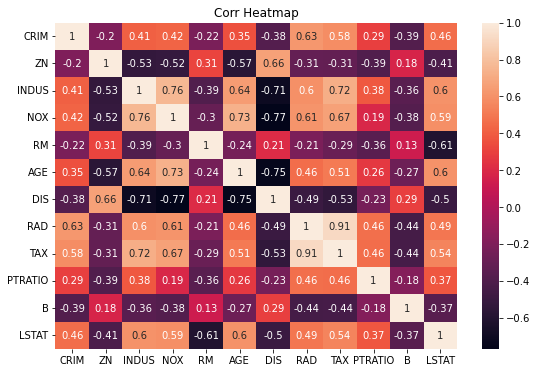

```python
f, ax = plt.subplots(figsize=(9, 6))
sns.heatmap(df[['CRIM', 'ZN', 'INDUS',
                'NOX', 'RM', 'AGE',
                'DIS', 'RAD', 'TAX',
                'PTRATIO', 'B', 'LSTAT']].corr(), annot=True, ax=ax)
plt.title('Corr Heatmap')
plt.show()
```

```python
df[['CRIM', 'ZN', 'INDUS',
    'NOX', 'RM', 'AGE',
    'DIS', 'RAD', 'TAX',
    'PTRATIO', 'B', 'LSTAT']].corr()
```

|  | CRIM | ZN | INDUS | NOX | RM | AGE | DIS | RAD | TAX | PTRATIO | B | LSTAT |
| --- | --- | --- | --- | --- | --- | --- | --- | --- | --- | --- | --- | --- |
| CRIM | 1.000000 | -0.200469 | 0.406583 | 0.420972 | -0.219247 | 0.352734 | -0.379670 | 0.625505 | 0.582764 | 0.289946 | -0.385064 | 0.455621 |
| ZN | -0.200469 | 1.000000 | -0.533828 | -0.516604 | 0.311991 | -0.569537 | 0.664408 | -0.311948 | -0.314563 | -0.391679 | 0.175520 | -0.412995 |
| INDUS | 0.406583 | -0.533828 | 1.000000 | 0.763651 | -0.391676 | 0.644779 | -0.708027 | 0.595129 | 0.720760 | 0.383248 | -0.356977 | 0.603800 |
| NOX | 0.420972 | -0.516604 | 0.763651 | 1.000000 | -0.302188 | 0.731470 | -0.769230 | 0.611441 | 0.668023 | 0.188933 | -0.380051 | 0.590879 |
| RM | -0.219247 | 0.311991 | -0.391676 | -0.302188 | 1.000000 | -0.240265 | 0.205246 | -0.209847 | -0.292048 | -0.355501 | 0.128069 | -0.613808 |
| AGE | 0.352734 | -0.569537 | 0.644779 | 0.731470 | -0.240265 | 1.000000 | -0.747881 | 0.456022 | 0.506456 | 0.261515 | -0.273534 | 0.602339 |
| DIS | -0.379670 | 0.664408 | -0.708027 | -0.769230 | 0.205246 | -0.747881 | 1.000000 | -0.494588 | -0.534432 | -0.232471 | 0.291512 | -0.496996 |
| RAD | 0.625505 | -0.311948 | 0.595129 | 0.611441 | -0.209847 | 0.456022 | -0.494588 | 1.000000 | 0.910228 | 0.464741 | -0.444413 | 0.488676 |
| TAX | 0.582764 | -0.314563 | 0.720760 | 0.668023 | -0.292048 | 0.506456 | -0.534432 | 0.910228 | 1.000000 | 0.460853 | -0.441808 | 0.543993 |
| PTRATIO | 0.289946 | -0.391679 | 0.383248 | 0.188933 | -0.355501 | 0.261515 | -0.232471 | 0.464741 | 0.460853 | 1.000000 | -0.177383 | 0.374044 |
| B | -0.385064 | 0.175520 | -0.356977 | -0.380051 | 0.128069 | -0.273534 | 0.291512 | -0.444413 | -0.441808 | -0.177383 | 1.000000 | -0.366087 |
| LSTAT | 0.455621 | -0.412995 | 0.603800 | 0.590879 | -0.613808 | 0.602339 | -0.496996 | 0.488676 | 0.543993 | 0.374044 | -0.366087 | 1.000000 |

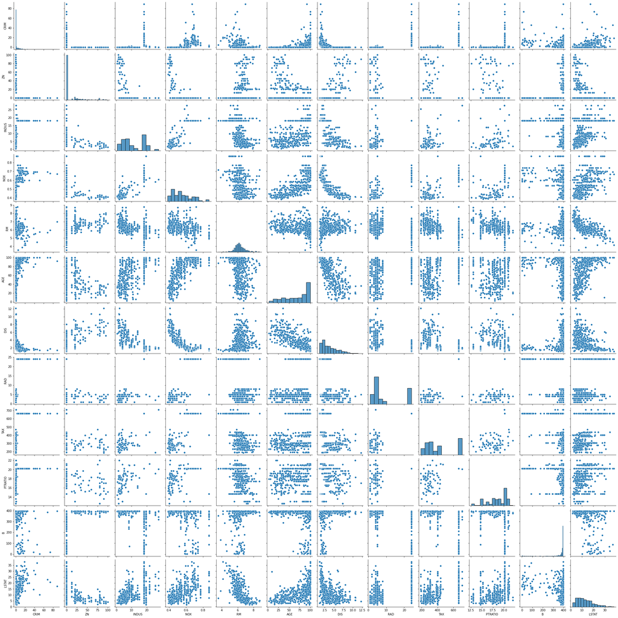

```python
sns.pairplot(df[['CRIM', 'ZN', 'INDUS',
                    'NOX', 'RM', 'AGE',
                    'DIS', 'RAD', 'TAX',
                    'PTRATIO', 'B', 'LSTAT']])
```

**Ejercicio:**  
Identificad los 2 atributos que tienen una correlación más fuerte con la respuesta y los 2 con una correlación más débil (coeficiente de correlación mayor o menor en valor absoluto). Para observar y analizar las correlaciones gráficamente, representad, para cada uno de los 4 atributos identificados, un scatter plot con el atributo en el eje x y la respuesta en el eje y. Además, en cada gráfico añadid la representación de una regresión lineal que fite los puntos.

Sugerencia: podéis usar la función "regplot" de la librería 'seaborn'.

```python
#Definimos una tabla de correlaciones entre el target y los features, posteriormente la ordenamos por el valor absoluto

pd.DataFrame(df.loc[:, df.columns != 'CHAS'].corr()["MEDV"]).sort_values(by="MEDV",key=abs)
```

|  | MEDV |
| --- | --- |
| DIS | 0.249929 |
| B | 0.333461 |
| ZN | 0.360445 |
| AGE | -0.376955 |
| RAD | -0.381626 |
| CRIM | -0.388305 |
| NOX | -0.427321 |
| TAX | -0.468536 |
| INDUS | -0.483725 |
| PTRATIO | -0.507787 |
| RM | 0.695360 |
| LSTAT | -0.737663 |
| MEDV | 1.000000 |

```python
#Definimos una función que nos ayude a graficar los scatter plots

def plotReg(df,x,y,title):
    """
    """
    ax = sns.regplot(x=x, y=y, ci=68, data=df,truncate=False)
    ax.set_title(title)
```

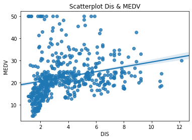

```python
plotReg(df, 'DIS', 'MEDV', 'Scatterplot Dis & MEDV')
```

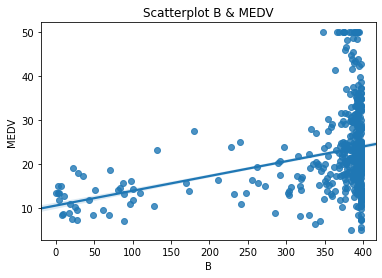

```python
plotReg(df, 'B', 'MEDV', 'Scatterplot B & MEDV')
```

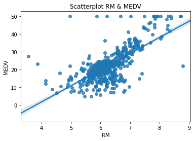

```python
plotReg(df, 'RM', 'MEDV', 'Scatterplot RM & MEDV')
```

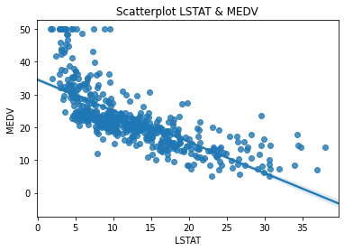

```python
plotReg(df, 'LSTAT', 'MEDV', 'Scatterplot LSTAT & MEDV')
```

**Análisis:**  
Observando los gráficos, comentad brevemente si conseguís ver las altas o bajas correlaciones que habíais identificado numéricamente.

Con respecto a las relaciones entre los features, en el heatmap y en la tabla de correlaciones podemos observar una alta correlación negativa entre las distancias hacia los centros de empleo de Boston y la concentración de óxido nítrico.

Por otra parte comentando las relaciones entre los features y el target, tenemos que las relaciones más bajas son justamente entre la distancia hacia los centros de empleo y la mediana de precios de las casas; la segunda variable con menor relación con el target es la proporción de gente afrodescendiente que reside en la zona.

Las relaciones más altas se observan entre el target y el número de habitaciones de la vivienda; % estado más bajo de la población.

# 3. Reducción de la dimensionalidad (3 puntos)

En este ejercicio se aplicarán métodos de reducción de la dimensionalidad al conjunto original de datos. El objetivo es reducir el conjunto de atributos a un nuevo conjunto con menos dimensiones, pero que contengan la máxima información posible presente en los atributos originales.

**Ejercicio:**

- Aplicad el método de reducción de la dimensionalidad Principal Component Analysis (PCA) para reducir a 2 dimensiones el dataset original que contiene todos los atributos.
- Generad un gráfico con el resultado del PCA en el que se muestre, en función de los valores de las dos componentes en los ejes x e y, el valor de la respuesta MEDV usando la escala de colores. El objetivo es visualizar la variación de MEDV en función de los valores de las componentes principales generadas.

NOTA: Vigilad de no incluir la variable objetivo "MEDV" en la reducción de dimensionalidad. Queremos poder explicar la variable objetivo en función del resto de variables reducidas a dos dimensiones.

Sugerencia: no es necesario que programéis el algoritmo de PCA, podéis usar la implementación disponible en la librería de "scikit-learn".  
Sugerencia: para el gráfico, podéis usar el scatter plot de matplotlib con el parámetro "c", que indica el color de los puntos, igual a la variable objetivo.

```python
from sklearn.preprocessing import StandardScaler

#Definimos X y estandarizamos

X = df[['CRIM', 'ZN', 'INDUS',
        'NOX', 'RM', 'AGE',
        'DIS', 'RAD', 'TAX',
        'PTRATIO', 'B', 'LSTAT','CHAS']].values

X = StandardScaler().fit_transform(X)

pca = PCA(n_components=2,)

principalComponents = pca.fit_transform(X)
principalDF = pd.DataFrame(data = principalComponents,
                           columns = ['p_1', 'p_2'])

#Concatenamos con el target
principalDF = pd.concat([principalDF, df[['MEDV']]], axis = 1)
principalDF.head()
```

|  | p_1 | p_2 | MEDV |
| --- | --- | --- | --- |
| 0 | -2.098297 | 0.773112 | 24.0 |
| 1 | -1.457252 | 0.591985 | 21.6 |
| 2 | -2.074598 | 0.599639 | 34.7 |
| 3 | -2.611504 | -0.006871 | 33.4 |
| 4 | -2.458185 | 0.097712 | 36.2 |

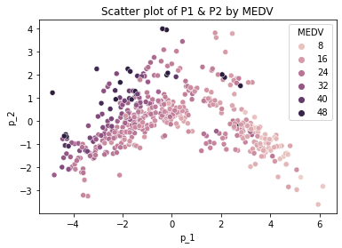

```python
sns.scatterplot(data=principalDF, x="p_1", y="p_2", hue='MEDV')
plt.title('Scatter plot of P1 & P2 by MEDV')
plt.show()
```

**Ejercicio:**

- Repetid la reducción de dimensionalidad, pero en este caso usando TSNE. Podéis encontrar más información sobre este algoritmo en el link: https://distill.pub/2016/misread-tsne/
- Igual que antes, generad un gráfico con el resultado del TSNE en el que se muestre, en función de los valores de las 2 nuevas dimensiones en los ejes x e y, el valor de la respuesta MEDV usando una escala de colores.

Sugerencia: no es necesario que programéis el algoritmo TSNE, podéis usar la implementación disponible en la librería de "scikit-learn".  
Sugerencia: a parte de especificar el número de componentes, probad a usar los parámetros "learning_rate" y "perplexity".  
Sugerencia: para el gráfico, podéis usar el scatter plot de matplotlib con el parámetro "c", que indica el color de los puntos, igual a la variable objetivo.

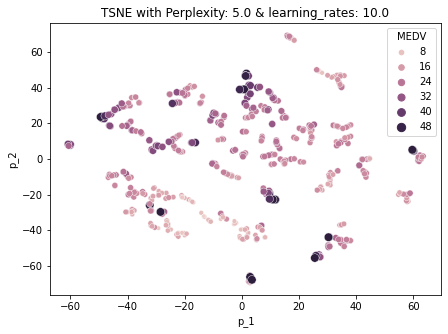

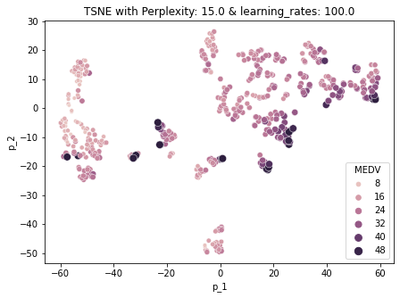

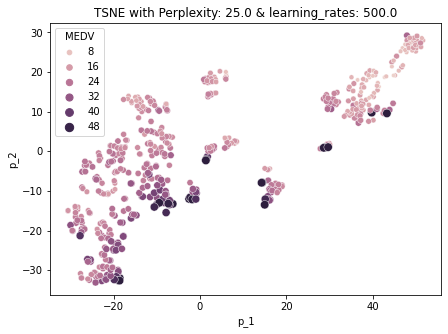

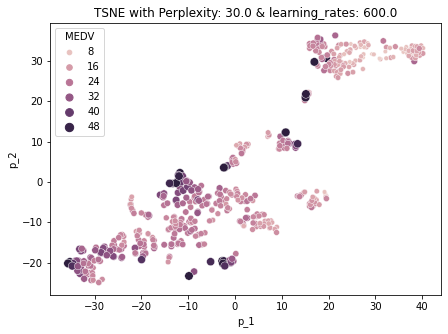

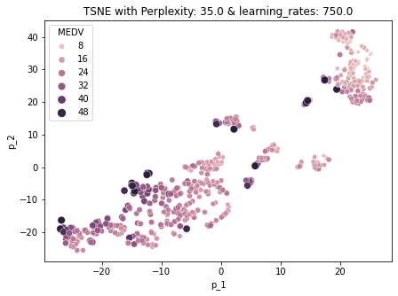

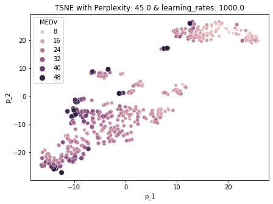

```python
#Definimos una lista con diferentes parámetros para testear

perplexitys = [5.0,15.0,25.0,30.0,35.0,45.0]
learning_rates = [10.0,100.00,500.00,600.00,750.00,1000.0]

results = []

#Definimos una función para generar los diferentes DFs producto de la reducción de dimensionalidad

def TSNE_func(data,n_components,perplexity,learning_rate):

    tsne = TSNE(n_components=n_components,
                perplexity=perplexity,
                learning_rate=learning_rate,
                random_state=seed,)

    TSNE_1 = tsne.fit_transform(data)

    TSNE_1DF = pd.DataFrame(data = TSNE_1,
                            columns = ['p_1', 'p_2'])

    TSNE_1 = pd.concat([TSNE_1DF, df[['MEDV']]], axis = 1)
    return TSNE_1

for i,e in zip(perplexitys, learning_rates):
    df_TSNE = TSNE_func(X,2,i,e)
    results.append(df_TSNE)


for i,e,o in zip(perplexitys,learning_rates,results):
    fig, ax = plt.subplots(figsize=(7,5))
    sns.scatterplot(data=o, x="p_1", y="p_2", hue="MEDV", size="MEDV", ax=ax)
    ax.set_title("TSNE with Perplexity: " + str(i) + " & " + "learning_rates: " + str(e))
    print()
```

**Análisis:**  
Observando los dos gráficos, ¿creéis que ha funcionado bien la reducción de dimensionalidad? ¿Os parece que las 2 nuevas dimensiones consiguen explicar la variación de MEDV y visualizar diferenciadamente precios caros y baratos? ¿Si utilizásemos las 2 nuevas variables para predecir MEDV, con cuál de los dos métodos de reducción de dimensionalidad creéis que obtendríamos los mejores resultados? ¿Por qué obtenemos resultados tan diferentes con los dos métodos?

Observando la serie de gráficos, se puede interpretar que en la medida que aumentas los parámetros perplexity y learning rate los puntos parecen agruparse en dos: precios altos/medios y precios bajos

# 4. Entrenamiento y test (3 puntos)

En este último ejercicio se trata de aplicar un método de aprendizaje supervisado, concretamente el Random Forest para regresión, para predecir la mediana del precio de cada zona y evaluar la precisión obtenida con el modelo. Para eso usaremos:

- El conjunto de datos original con todos los atributos
- El conjunto de datos reducido a sólo 2 atributos con PCA
- El conjunto de datos reducido a sólo 2 atributos con TSNE

**Ejercicio:**  
Usando el conjunto de datos original:

- Dividid el dataset en train y test utilizando la semilla definida al inicio del notebook (seed).
- Definid un modelo Random Forest (fijando n_estimators=10 para mantener el modelo simple y random_state=seed).
- Aplicad validación cruzada con el modelo definido y el dataset de train (con cv=5 ya es suficiente).
- Como métrica para cuantificar el error del modelo, utilizad tanto R2 (coeficiente de determinación) como MAE (la media del error absoluto) separadamente
- Calculad la media y la desviación standard del error obtenido en cada caso.

Sugerencia: para separar entre train y test podéis usar 'train_test_split' de sklearn.  
Sugerencia: para entrenar un modelo random forest podéis usar 'RandomForestRegressor' de sklearn.  
Sugerencia: para aplicar validación cruzada podéis usar 'cross_val_score' de sklearn, y modificar su parámetro 'scoring' si fuese necesario.

```python
from sklearn.model_selection import cross_validate

df_original = df
X_original = df_original[['CRIM', 'ZN', 'INDUS',
                        'NOX', 'RM', 'AGE',
                        'DIS', 'RAD', 'TAX',
                        'PTRATIO', 'B', 'LSTAT','CHAS']].values

y_original = df_original[['MEDV']].values.ravel()

X_train, X_test, y_train, y_test = train_test_split(X_original,
                                                    y_original,
                                                    test_size = 0.3,
                                                    random_state = seed)

regressor = RandomForestRegressor(n_estimators = 10,
                                  random_state = seed)

data_scoresOriginal = cross_validate(regressor, X_train, y_train, cv=5,
                                     scoring=['neg_mean_absolute_error','r2'])

data_scoresOriginal = pd.DataFrame(data_scoresOriginal)
data_scoresOriginal
```

|  | fit_time | score_time | test_neg_mean_absolute_error | test_r2 |
| --- | --- | --- | --- | --- |
| 0 | 0.032002 | 0.002002 | -2.404225 | 0.814489 |
| 1 | 0.031000 | 0.002002 | -2.523803 | 0.865913 |
| 2 | 0.027001 | 0.002001 | -2.060986 | 0.906456 |
| 3 | 0.029001 | 0.002000 | -2.311690 | 0.856050 |
| 4 | 0.024002 | 0.002002 | -3.028143 | 0.733975 |

```python
data_scoresOriginal.describe()
```

|  | fit_time | score_time | test_neg_mean_absolute_error | test_r2 |
| --- | --- | --- | --- | --- |
| count | 5.000000 | 5.000000e+00 | 5.000000 | 5.000000 |
| mean | 0.028601 | 2.001286e-03 | -2.465769 | 0.835376 |
| std | 0.003209 | 6.078505e-07 | 0.357425 | 0.065442 |
| min | 0.024002 | 2.000332e-03 | -3.028143 | 0.733975 |
| 25% | 0.027001 | 2.001047e-03 | -2.523803 | 0.814489 |
| 50% | 0.029001 | 2.001524e-03 | -2.404225 | 0.856050 |
| 75% | 0.031000 | 2.001762e-03 | -2.311690 | 0.865913 |
| max | 0.032002 | 2.001762e-03 | -2.060986 | 0.906456 |

**Ejercicio:**  
Repetid el mismo procedimiento que en el ejercicio anterior con el dataset reducido a 2 dimensiones con PCA.

```python
#Definimos una función para correr la validación cruzada.

def CrossValidation(X_train, y_train, regressor):
    data_scores = cross_validate(regressor, X_train, y_train, cv=5, scoring=['neg_mean_absolute_error','r2'])
    return pd.DataFrame(data_scores)
```

```python
principalDF.sample(2)
```

|  | p_1 | p_2 | MEDV |
| --- | --- | --- | --- |
| 44 | -1.916313 | -0.141893 | 21.2 |
| 148 | 2.519810 | 1.758306 | 17.8 |

```python
regressor = RandomForestRegressor(n_estimators = 10, random_state = seed)

X_principalComponents = principalDF[["p_1","p_2"]].values
y_principalComponents = principalDF[['MEDV']].values.ravel()

X_train, X_test, y_train, y_test = train_test_split(X_principalComponents,
                                                    y_principalComponents,
                                                    test_size = 0.3,
                                                    random_state = seed)

dataScores_principalComponents = CrossValidation(X_train,y_train,regressor)
dataScores_principalComponents
```

|  | fit_time | score_time | test_neg_mean_absolute_error | test_r2 |
| --- | --- | --- | --- | --- |
| 0 | 0.022001 | 0.001998 | -3.057042 | 0.647693 |
| 1 | 0.015001 | 0.002000 | -4.584225 | 0.406379 |
| 2 | 0.015001 | 0.002000 | -3.680845 | 0.670537 |
| 3 | 0.014001 | 0.002000 | -3.288451 | 0.736699 |
| 4 | 0.015001 | 0.002001 | -4.553714 | 0.478186 |

```python
dataScores_principalComponents.describe()
```

|  | fit_time | score_time | test_neg_mean_absolute_error | test_r2 |
| --- | --- | --- | --- | --- |
| count | 5.000000 | 5.000000e+00 | 5.000000 | 5.000000 |
| mean | 0.016201 | 1.999998e-03 | -3.832856 | 0.587899 |
| std | 0.003271 | 8.856857e-07 | 0.708090 | 0.139223 |
| min | 0.014001 | 1.998425e-03 | -4.584225 | 0.406379 |
| 25% | 0.015001 | 2.000332e-03 | -4.553714 | 0.478186 |
| 50% | 0.015001 | 2.000332e-03 | -3.680845 | 0.647693 |
| 75% | 0.015001 | 2.000332e-03 | -3.288451 | 0.670537 |
| max | 0.022001 | 2.000570e-03 | -3.057042 | 0.736699 |

**Ejercicio:**  
Repetid el mismo procedimiento que en el ejercicio anterior con el dataset reducido a 2 dimensiones con TSNE.

```python
#Utilizamos el TSNE que separó más los puntos en dos grupos

df_TSNE = TSNE_func(X,2,45.0,1000.0)
df_TSNE.sample(2)
```

|  | p_1 | p_2 | MEDV |
| --- | --- | --- | --- |
| 473 | 10.529292 | 21.347544 | 29.8 |
| 276 | -6.444997 | 8.433619 | 33.2 |

```python
X_TSNE = df_TSNE[["p_1","p_2"]].values
y_TSNE = df_TSNE[['MEDV']].values.ravel()

X_train, X_test, y_train, y_test = train_test_split(X_TSNE,
                                                    y_TSNE,
                                                    test_size = 0.3,
                                                    random_state = seed)


dataScores_df_TSNE = CrossValidation(X_train, y_train,regressor)
dataScores_df_TSNE
```

|  | fit_time | score_time | test_neg_mean_absolute_error | test_r2 |
| --- | --- | --- | --- | --- |
| 0 | 0.027000 | 0.001999 | -3.017746 | 0.716179 |
| 1 | 0.022002 | 0.002001 | -3.589718 | 0.570638 |
| 2 | 0.021002 | 0.002000 | -2.798310 | 0.818092 |
| 3 | 0.016004 | 0.002000 | -2.840423 | 0.765497 |
| 4 | 0.015000 | 0.002000 | -3.257286 | 0.747310 |

```python
dataScores_df_TSNE.describe()
```

|  | fit_time | score_time | test_neg_mean_absolute_error | test_r2 |
| --- | --- | --- | --- | --- |
| count | 5.000000 | 5.000000e+00 | 5.000000 | 5.000000 |
| mean | 0.020201 | 1.999950e-03 | -3.100697 | 0.723543 |
| std | 0.004868 | 4.943953e-07 | 0.327766 | 0.093138 |
| min | 0.015000 | 1.999378e-03 | -3.589718 | 0.570638 |
| 25% | 0.016004 | 1.999617e-03 | -3.257286 | 0.716179 |
| 50% | 0.021002 | 1.999855e-03 | -3.017746 | 0.747310 |
| 75% | 0.022002 | 2.000332e-03 | -2.840423 | 0.765497 |
| max | 0.027000 | 2.000570e-03 | -2.798310 | 0.818092 |

**Análisis:**  
¿Con qué datos ha funcionado mejor? ¿Tiene sentido? ¿Cuadra con los resultados que hemos visto en el ejercicio 3?

```python
results = [data_scoresOriginal, dataScores_principalComponents, dataScores_df_TSNE]
names = ["Datos Originales", "Datos con PCA", "Datos con TSNE"]

for i,e in zip(results, names):
    print("------")
    print(e)
    print(i.describe())
```

```
------
Datos Originales
       fit_time    score_time  test_neg_mean_absolute_error   test_r2
count  5.000000  5.000000e+00                      5.000000  5.000000
mean   0.028601  2.001286e-03                     -2.465769  0.835376
std    0.003209  6.078505e-07                      0.357425  0.065442
min    0.024002  2.000332e-03                     -3.028143  0.733975
25%    0.027001  2.001047e-03                     -2.523803  0.814489
50%    0.029001  2.001524e-03                     -2.404225  0.856050
75%    0.031000  2.001762e-03                     -2.311690  0.865913
max    0.032002  2.001762e-03                     -2.060986  0.906456
------
Datos con PCA
       fit_time    score_time  test_neg_mean_absolute_error   test_r2
count  5.000000  5.000000e+00                      5.000000  5.000000
mean   0.016201  1.999998e-03                     -3.832856  0.587899
std    0.003271  8.856857e-07                      0.708090  0.139223
min    0.014001  1.998425e-03                     -4.584225  0.406379
25%    0.015001  2.000332e-03                     -4.553714  0.478186
50%    0.015001  2.000332e-03                     -3.680845  0.647693
75%    0.015001  2.000332e-03                     -3.288451  0.670537
max    0.022001  2.000570e-03                     -3.057042  0.736699
------
Datos con TSNE
       fit_time    score_time  test_neg_mean_absolute_error   test_r2
count  5.000000  5.000000e+00                      5.000000  5.000000
mean   0.020201  1.999950e-03                     -3.100697  0.723543
std    0.004868  4.943953e-07                      0.327766  0.093138
min    0.015000  1.999378e-03                     -3.589718  0.570638
25%    0.016004  1.999617e-03                     -3.257286  0.716179
50%    0.021002  1.999855e-03                     -3.017746  0.747310
75%    0.022002  2.000332e-03                     -2.840423  0.765497
max    0.027000  2.000570e-03                     -2.798310  0.818092
```

Tomando en cuenta el R2 tenemos que el mejor modelo es el que utiliza los features originales, de esta forma el modelo explica mayor porcentaje de varianza del target. Esto puede deberse a que al realizar una reducción de dimensiones se pierde cierta cantidad de información en pos de tener una menor cantidad de variables independientes para explicar el fenómeno. Teniendo en cuenta el MAE, el modelo con los datos originales también tiene la mejor performance, seguido del modelo que utilizó TSNE para la reducción de dimensiones.

**Ejercicio:**  
Con el mejor modelo que hayáis obtenido:

- Generad predicciones sobre el dataset de test.
- Calculad la precisión de las predicciones obtenidas (R2 y MAE).

Sugerencia: para calcular R2 y MAE podéis usar las funciones dentro del módulo "metrics" de sklearn.

```python
#Corremos el mejor modelo

df_original = df
X_original = df_original[['CRIM', 'ZN', 'INDUS',
                        'NOX', 'RM', 'AGE',
                        'DIS', 'RAD', 'TAX',
                        'PTRATIO', 'B', 'LSTAT','CHAS']].values

y_original = df_original[['MEDV']].values.ravel()

X_train, X_test, y_train, y_test = train_test_split(X_original,
                                                    y_original,
                                                    test_size = 0.3,
                                                    random_state = seed)

regressor = RandomForestRegressor(n_estimators = 10,
                                  random_state = seed)
regressor.fit(X_train, y_train)
y_pred = regressor.predict(X_test)
```

```python
from sklearn.metrics import mean_absolute_error

print("El valor del MAE es: {}".format(round(mean_absolute_error(y_test, y_pred),4)))
```

```
El valor del MAE es: 3.6171
```

```python
from sklearn.metrics import r2_score


print("El valor del R2 es: {}".format(round(r2_score(y_test, y_pred),4)))
```

```
El valor del R2 es: 0.7949
```

**Análisis:**  
¿Cuál de las dos métricas propuestas para evaluar los modelos (R2 o MAE) utilizaríais para explicar lo bueno que es el modelo a un ejecutivo de una inmobiliaria? ¿Y para explicarlo a un analista matemático de la misma compañía? Por qué?

Para explicarle al ejecutivo de la inmobiliaria utilizaría el R2, debido a que es una métrica un poco más fácil de explicar: 79% de la variabilidad de la mediana de los precios de las propiedades, queda explicado por los features o atributos utilizados y el modelo de ramdonforest En el caso del matemático elijo el MAE para que entienda en promedio, qué tan lejos están las predicciones del valor real.

**BONUS:**  
El modelo random forest depende de muchos parámetros. En este ejercicio sólo hemos especificado el número de árboles (n_estimators) y hemos dejado que usara el resto de parámetros por defecto. Dos parámetros muy útiles en los random forest (y en cualquier modelo que use árboles) son el max_depth y el min_samples_split. Estos parámetros ayudan a controlar el overfitting. Entrenad los modelos anteriores usando diferentes combinaciones de los parámetros:

- n_estimators
- max_depth
- min_samples_split

con el objetivo de encontrar la combinación de parámetros que da los mejores resultados en el conjunto de datos de entrenamiento. Para el modelo con la mejor combinación de parámetros, calculad las métricas de error (R2 y MAE) en el conjunto de datos de test.

Sugerencia: Podéis utilizar GridSearchCV dentro del módulo "model_selection" de sklearn.

```python
from sklearn.model_selection import GridSearchCV

X = df_original[['CRIM', 'ZN', 'INDUS',
                        'NOX', 'RM', 'AGE',
                        'DIS', 'RAD', 'TAX',
                        'PTRATIO', 'B', 'LSTAT','CHAS']].values

y = df_original[['MEDV']].values.ravel()


#tuned_parameters = {'n_estimators': [10,100,500,700,1000],
#                    'max_depth': [1,3,6,9],
#                    'min_samples_split': [1]}
# Se intentó correr este, pero tarda mucho tiempo en ejecutarse.

tuned_parameters = {'n_estimators': [10,20,30,100,150],
                    'max_depth': [3,6,9],
                    'min_samples_split': [0.20,0.50,1.0]}


model = GridSearchCV(RandomForestRegressor(random_state = seed),
                        param_grid = tuned_parameters,
                        scoring = 'neg_mean_absolute_error',
                        n_jobs=-1)

model.fit(X, y)
```

```
GridSearchCV(estimator=RandomForestRegressor(random_state=100), n_jobs=-1,
             param_grid={'max_depth': [3, 6, 9],
                         'min_samples_split': [0.2, 0.5, 1.0],
                         'n_estimators': [10, 20, 30, 100, 150]},
             scoring='neg_mean_absolute_error')
```

```python
modelos = pd.DataFrame(model.cv_results_)
modelos = modelos.sort_values('rank_test_score',ascending=True).head()
modelos
```

|  | mean_fit_time | std_fit_time | mean_score_time | std_score_time | param_max_depth | param_min_samples_split | param_n_estimators | params | split0_test_score | split1_test_score | split2_test_score | split3_test_score | split4_test_score | mean_test_score | std_test_score | rank_test_score |
| --- | --- | --- | --- | --- | --- | --- | --- | --- | --- | --- | --- | --- | --- | --- | --- | --- |
| 33 | 0.306628 | 0.008453 | 0.016111 | 0.001634 | 9 | 0.2 | 100 | {'max_depth': 9, 'min_samples_split': 0.2, 'n_... | -2.456272 | -3.004929 | -4.731914 | -4.548651 | -4.027363 | -3.753825 | 0.884050 | 1 |
| 18 | 0.296827 | 0.018871 | 0.014206 | 0.000929 | 6 | 0.2 | 100 | {'max_depth': 6, 'min_samples_split': 0.2, 'n_... | -2.455312 | -3.003021 | -4.737176 | -4.548472 | -4.028130 | -3.754422 | 0.885836 | 2 |
| 34 | 0.497829 | 0.022611 | 0.023306 | 0.001398 | 9 | 0.2 | 150 | {'max_depth': 9, 'min_samples_split': 0.2, 'n_... | -2.490149 | -3.016253 | -4.808246 | -4.556279 | -4.039103 | -3.782006 | 0.891520 | 3 |
| 19 | 0.463346 | 0.025546 | 0.024613 | 0.003896 | 6 | 0.2 | 150 | {'max_depth': 6, 'min_samples_split': 0.2, 'n_... | -2.488199 | -3.015433 | -4.815881 | -4.556110 | -4.039546 | -3.783034 | 0.893983 | 4 |
| 3 | 0.282955 | 0.015789 | 0.021802 | 0.004534 | 3 | 0.2 | 100 | {'max_depth': 3, 'min_samples_split': 0.2, 'n_... | -2.515841 | -3.110529 | -4.823051 | -4.470160 | -4.032056 | -3.790327 | 0.857154 | 5 |

```python
modelos.iloc[0]["params"]
```

```
{'max_depth': 9, 'min_samples_split': 0.2, 'n_estimators': 100}
```

```python
df_original = df
X_original = df_original[['CRIM', 'ZN', 'INDUS',
                        'NOX', 'RM', 'AGE',
                        'DIS', 'RAD', 'TAX',
                        'PTRATIO', 'B', 'LSTAT','CHAS']].values

y_original = df_original[['MEDV']].values.ravel()

X_train, X_test, y_train, y_test = train_test_split(X_original,
                                                    y_original,
                                                    test_size = 0.3,
                                                    random_state = seed)

regressor = RandomForestRegressor(n_estimators = 100,
                                  max_depth = 9,
                                  min_samples_split= 0.2,
                                  random_state = seed)
regressor.fit(X_train, y_train)
y_pred = regressor.predict(X_test)

print("El valor del MAE es: {}".format(round(mean_absolute_error(y_test, y_pred),4)))
print("El valor del R2 es: {}".format(round(r2_score(y_test, y_pred),4)))
```

[output not shown]

Empeora la performance del mejor modelo del Grid Search

```python
#Corremos de nuevo el grid search pero con el scoring de R2

model = GridSearchCV(RandomForestRegressor(random_state = seed),
                        param_grid = tuned_parameters,
                        scoring = 'r2',
                        n_jobs=-1)

model.fit(X, y)

modelos = pd.DataFrame(model.cv_results_)
modelos = modelos.sort_values('rank_test_score',ascending=True).head()
modelos.iloc[0]["params"]
```

```
{'max_depth': 9, 'min_samples_split': 0.2, 'n_estimators': 100}
```

**BONUS:**  
¿Habéis conseguido mejorar el modelo? ¿Cuál ha sido el impacto de variar cada parámetro en la precisión del modelo?